# Mummichog Report: data_pos_both_after_blank_subtraction

mummichog version: 2.2.0-20200207, using metabolic model MFN_1.10.4.

## User input data

User supplied 815 features as reference list.We are using 268 features (p < 0.050000) as significant list. The feature level data are shown in the Manhattan plots below.

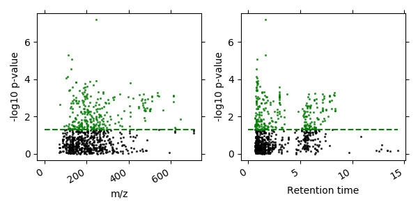

## Top pathways

The reference feature list is mapped to 158 EmpiricalCompounds, significant features to 62 EmpiricalCompounds. In the table below, pathway_size is number of detected EmpiricalCompounds for each pathway; overlap_size is number of significant EmpiricalCompounds. Empirical p-values are estimated by permutation test. Details on EmpiricalCompounds are in 'tables/ListOfEmpiricalCompounds.tsv'.

| Pathways | overlap_size | pathway_size | p-value | overlap_EmpiricalCompounds |
| --- | --- | --- | --- | --- |
| Drug metabolism - cytochrome P450 | 3 | 3 | 0.01008 | E89,E50,E187 |
| Lipoate metabolism | 2 | 2 | 0.04134 | E79,E64 |
| Aminosugars metabolism | 4 | 6 | 0.04764 | E5,E96,E302,E110 |
| Vitamin B9 (folate) metabolism | 3 | 4 | 0.04823 | E96,E302,E114 |
| Porphyrin metabolism | 3 | 4 | 0.04823 | E182,E264,E114 |

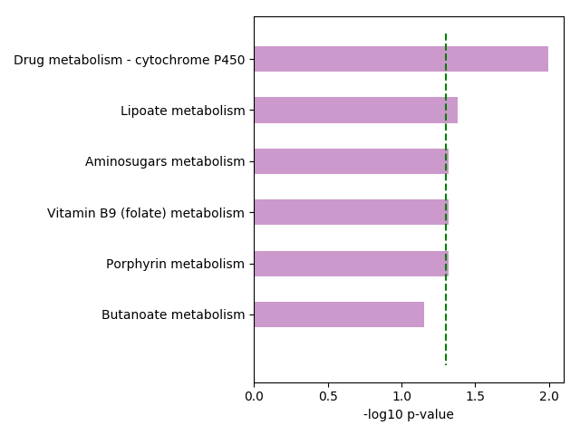

## EmpiricalCompounds favored by above analyses

An EmpiricalCompound is a computational unit for a tentative metabolite. It can group multiple ions, and be any of the isobaric/isomeric species. This table contains EmpiricalCompounds prioritized by pathway/module analysis.

| EmpiricalCompound | Input m/z | Retention time | ion | mz_diff | Statistic | Significant |
| --- | --- | --- | --- | --- | --- | --- |
| E110 | Best guess: C00270, N-Acetylneuraminate |  | C00270 |  |  |  |
|  | 310.112753179 | 0.900255555556 | M+H[1+] | -0.0005 | 2.47 | yes |
|  | 332.095432132 | 0.882408823529 | M+Na[1+] | 0.0002 | -0.39 | no |
| E114 | Best guess: C01042, N-Acetyl-L-aspartate |  | C05520, C01045, C01042 |  |  |  |
|  | 176.05561917 | 1.54583070175 | M+H[1+] | 0.0002 | 2.15 | yes |
|  | 198.037360827 | 1.54554473684 | M+Na[1+] | -0.0 | 2.53 | yes |
| E64 | Best guess: C00725, Lipoate |  | C04593, C02225, C00725 |  |  |  |
|  | 207.050971985 | 0.735034375 | M+H[1+] | 0.0002 | -3.21 | yes |
| E302 | Best guess: C00302, DL-Glutamate |  | C00217, C05938, C00025, C00302 |  |  |  |
|  | 148.060738731 | 2.9864 | M+H[1+] | 0.0003 | -4.15 | yes |
|  | 148.06072817 | 2.93435882353 | M+H[1+] | 0.0003 | -0.51 | no |
| E264 | Best guess: C01110, 5-Amino-2-oxopentanoic acid |  | C00430, C03440, C01157, C03341, C01165, C01110 |  |  |  |
|  | 154.047451052 | 2.30540075758 | M+Na[1+] | -0.0 | -2.3 | yes |
| E79 | Best guess: C00047, L-Lysine |  | C00047 |  |  |  |
|  | 147.113034939 | 0.689177272727 | M+H[1+] | 0.0003 | -2.18 | yes |
| E182 | Best guess: C02670, D-glucurono-6,3-lactone |  | glac, C00072, C02670 |  |  |  |
|  | 177.039696334 | 1.24831315789 | M+H[1+] | 0.0003 | 2.39 | yes |
|  | 199.021541595 | 1.2479 | M+Na[1+] | 0.0002 | 2.72 | yes |
| E5 | Best guess: CE3075, sorbitol 3-phosphate |  | C05345, C00085, C00103, C02976, C01171, C01177, C03735, C00636, C00092, C01172, C03862, C04006, C01097, C01094, C00668, C03546, C00446, C02965, C00275, CE3075 |  |  |  |
|  | 283.019034386 | 0.824247916667 | M+Na[1+] | 0.0 | 2.15 | yes |
| E50 | Best guess: C16587, 3-Carbamoyl-2-phenylpropionaldehyde |  | C16595, C16587 |  |  |  |
|  | 216.063360444 | 0.792421568627 | M+Na[1+] | 0.0002 | -5.2 | yes |
| E187 | Best guess: C05635, 5-Hydroxyindoleacetate |  | C16596, C05635 |  |  |  |
|  | 192.065716295 | 6.97164509804 | M+H[1+] | 0.0002 | -3.25 | yes |
| E89 | Best guess: C16584, p-Hydroxyfelbamate |  | C16582, C16584 |  |  |  |
|  | 255.097476578 | 1.52667395833 | M+H[1+] | -0.0001 | -4.53 | yes |
| E96 | Best guess: C00302, DL-Glutamate |  | C00217, C05938, C00025, C00302 |  |  |  |
|  | 148.060497936 | 0.827882575758 | M+H[1+] | 0.0 | 5.15 | yes |

## More data

Full data tables from pathway analysis, module analysis and activity network are stored in the 'tables/' directory. The tsv files can be imported into a spreadsheet program, e.g. MS Excel. Under the 'figures/network_modules/' directory are files intended for Cytoscape (cytoscape.org) visualization. Please refer to Cytoscape's guides for details. Details of this run are recorded in file mummichog.log.txt.